# Receipt analysis (post-study)

Remco Benthem de Grave

2024-01-16

## Descriptives

### Receipt level descriptives

Those scanned in the app (not the pre-loaded receipts).

```
##
##
## RECEIPT DESCRIPTIVES
```

```
##
##
## Number of receipts scanned in the app: 95
```

```
##
##
## Descriptives:
##
##     (1)number of days after start of participation that the receipt was scanned,
##
##     (2)weight-corrected average product footprint in gCO2/100g,
##
##     (3)basket footprint in gCO2 (aka. combined carbon footprint of all products in the basket)
##
##     (4)basket weight in grams (aka. combined weight of all products in the basket)
##
##     (5)number of items on a receipt
##
##
##
```

```
##   day_recorded     rcpt_CO2_g_100g   rcpt_CO2_kg      rcpt_weight_kg
##  Min.   : 0.4735   Min.   :  55.0   Min.   :  0.460   Min.   : 0.500
##  1st Qu.: 6.0635   1st Qu.: 153.0   1st Qu.:  6.585   1st Qu.: 2.740
##  Median :11.3305   Median : 216.1   Median : 11.017   Median : 5.467
##  Mean   :11.0745   Mean   : 280.0   Mean   : 17.335   Mean   : 6.712
##  3rd Qu.:15.1014   3rd Qu.: 298.1   3rd Qu.: 21.907   3rd Qu.: 9.110
##  Max.   :26.1591   Max.   :1525.9   Max.   :109.811   Max.   :20.260
##   rcpt_items_n
##  Min.   : 1.00
##  1st Qu.: 3.50
##  Median :11.00
##  Mean   :13.86
##  3rd Qu.:18.00
##  Max.   :84.00
```

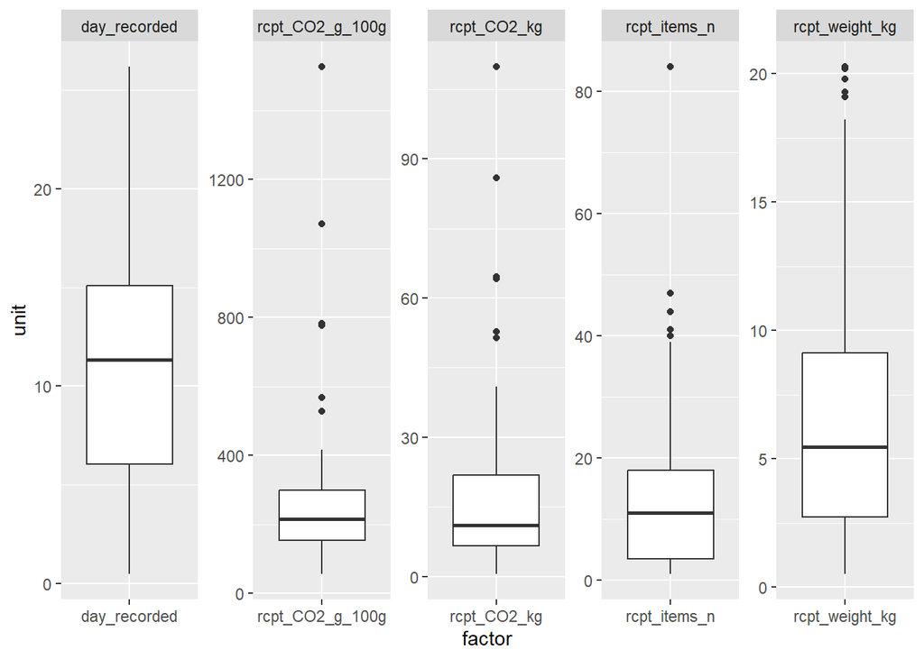

### Receipt level descriptives grouped by household

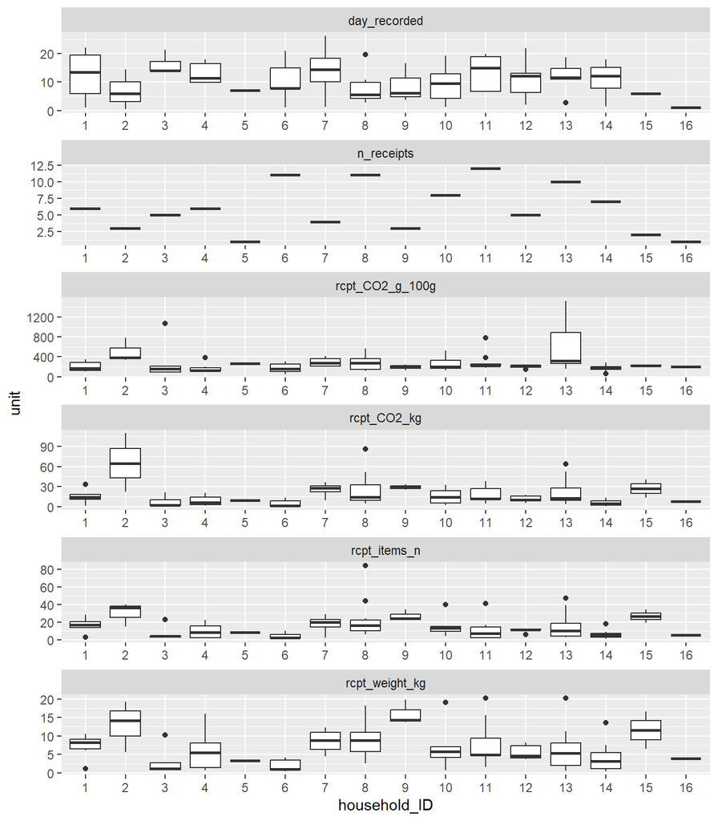

### Household level descriptives (aggregated receipts)

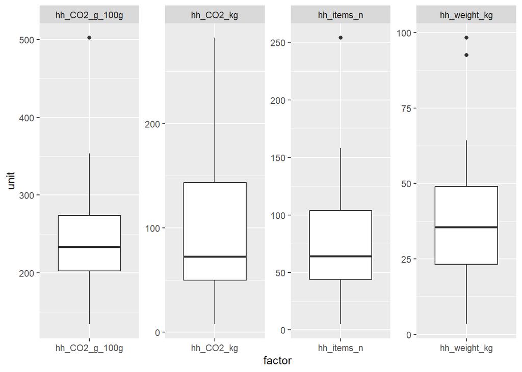

## Visualize foodprint change

This considers the weight-balanced average carbon footprint of receipts.

### Time since enrollment

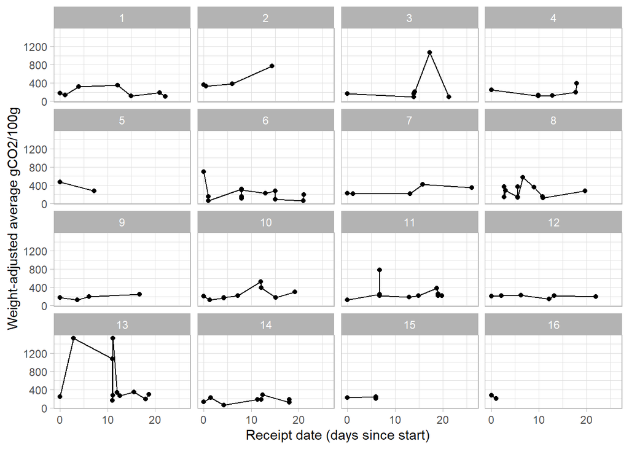

A visual analysis does not suggest any clear change in foodprint. Note, facet labels are the household ID.

## Sequence of receipts

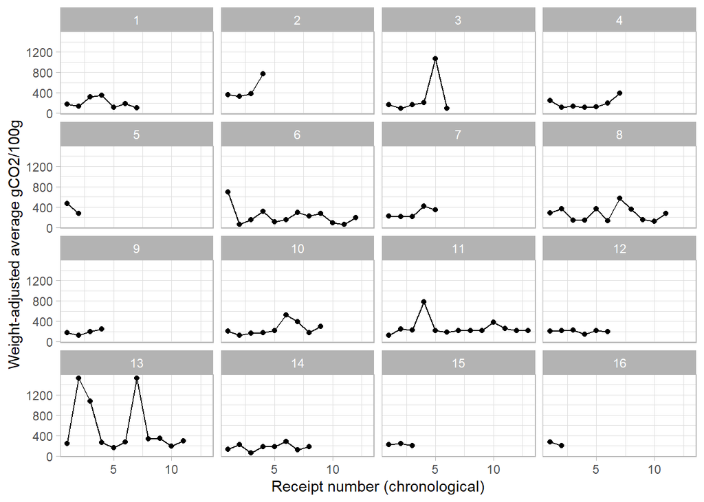

A visual analysis does not suggest any clear change in foodprint.

## Determine whether there is statistical evidence of footprint changing over time

### Using mixed-model statistics (parametric)

#### With receipt ID as time factor

##### The model

```
##
##
##  FULL MIXED MODEL (including time factor)
```

```
## boundary (singular) fit: see help('isSingular')
```

```
## Linear mixed model fit by REML ['lmerMod']
## Formula: rcpt_CO2_g_100g ~ hh_receipt_id + (1 + hh_receipt_id | household_ID)
##    Data: receipt_data
##
## REML criterion at convergence: 1497.8
##
## Scaled residuals:
##     Min      1Q  Median      3Q     Max
## -1.5203 -0.4620 -0.1951  0.0983  4.8990
##
## Random effects:
##  Groups       Name          Variance Std.Dev. Corr
##  household_ID (Intercept)   17081.08 130.69
##               hh_receipt_id    77.09   8.78   -1.00
##  Residual                   49871.66 223.32
## Number of obs: 110, groups:  household_ID, 16
##
## Fixed effects:
##               Estimate Std. Error t value
## (Intercept)    293.209     51.296   5.716
## hh_receipt_id   -3.933      7.351  -0.535
##
## Correlation of Fixed Effects:
##             (Intr)
## hh_recept_d -0.801
## optimizer (nloptwrap) convergence code: 0 (OK)
## boundary (singular) fit: see help('isSingular')
```

##### Diagnostics (assessing heterogenity and normal distrubution of residuals)

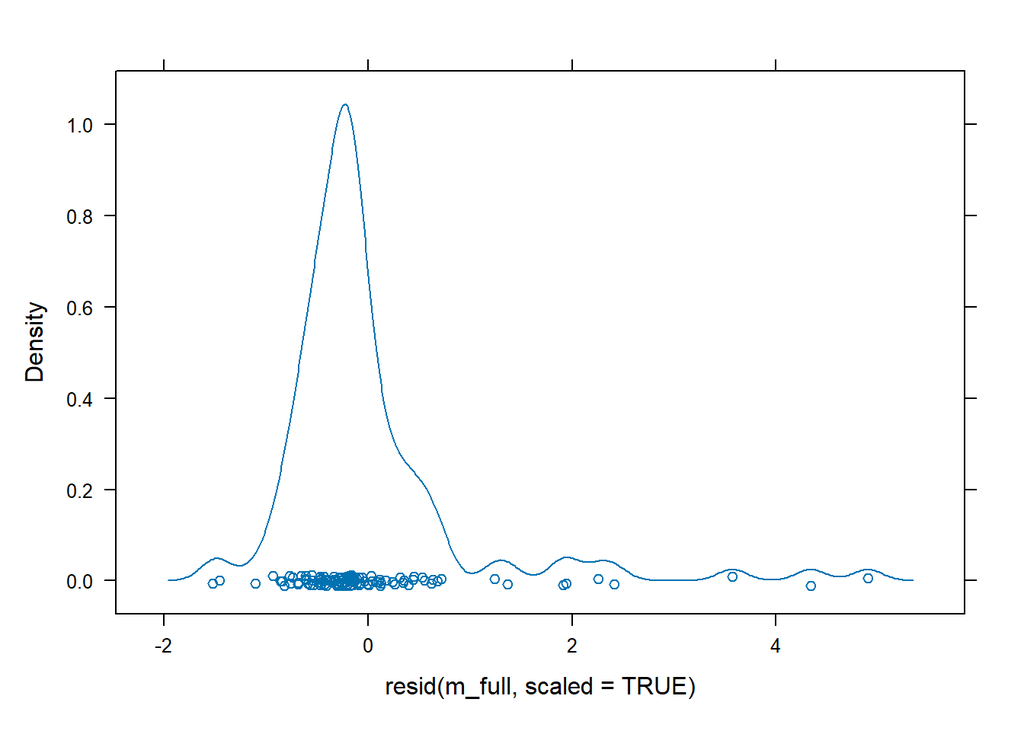

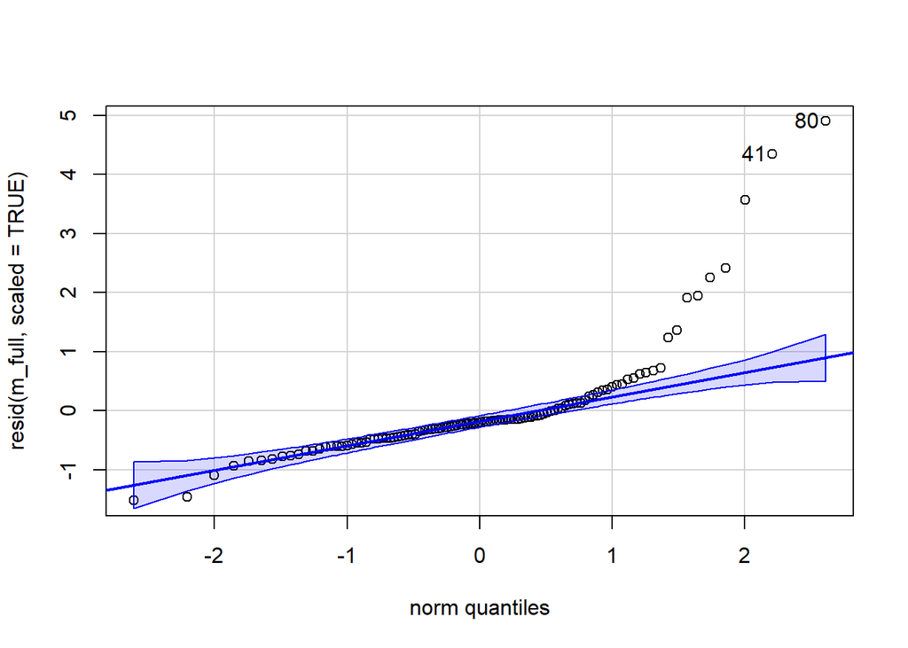

```
## [1] 80 41
```

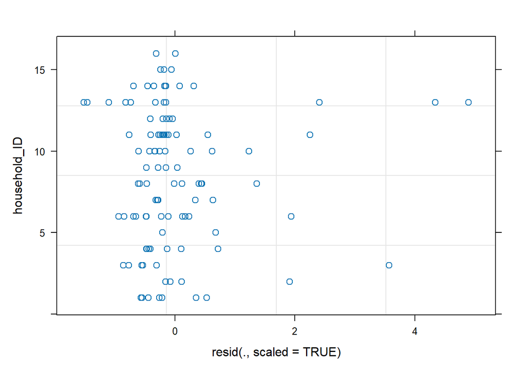

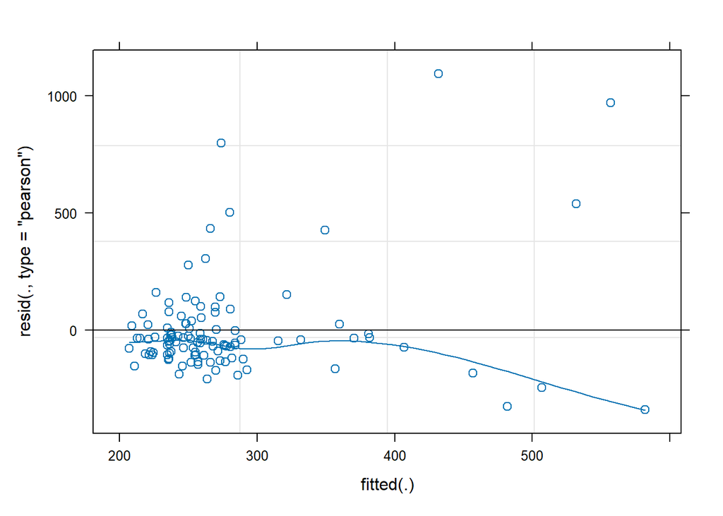

There are indications of outliers and non-normality, so results should be interpreted with caution.

##### Statistical inference of time effect

```
## refitting model(s) with ML (instead of REML)
```

```
## Data: receipt_data
## Models:
## m_null: rcpt_CO2_g_100g ~ 1 + (1 | household_ID)
## m_full: rcpt_CO2_g_100g ~ hh_receipt_id + (1 + hh_receipt_id | household_ID)
##        npar    AIC    BIC  logLik deviance  Chisq Df Pr(>Chisq)
## m_null    3 1520.0 1528.1 -757.00   1514.0
## m_full    6 1524.3 1540.5 -756.16   1512.3 1.6669  3     0.6443
```

We find no indication of significance.

#### With time since household enrollment as independent variable.

##### The model

```
## boundary (singular) fit: see help('isSingular')
```

[output not shown]

##### Diagnostics (assessing heterogenity and normal distrubution of residuals)

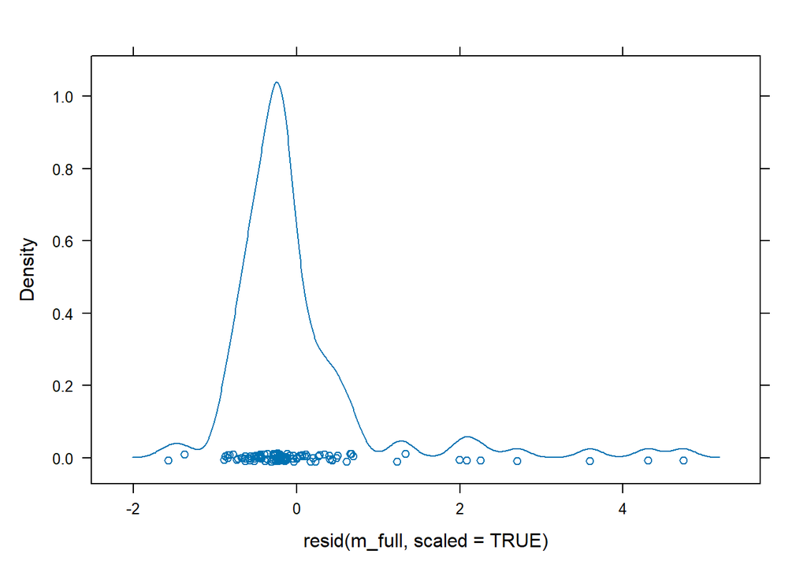

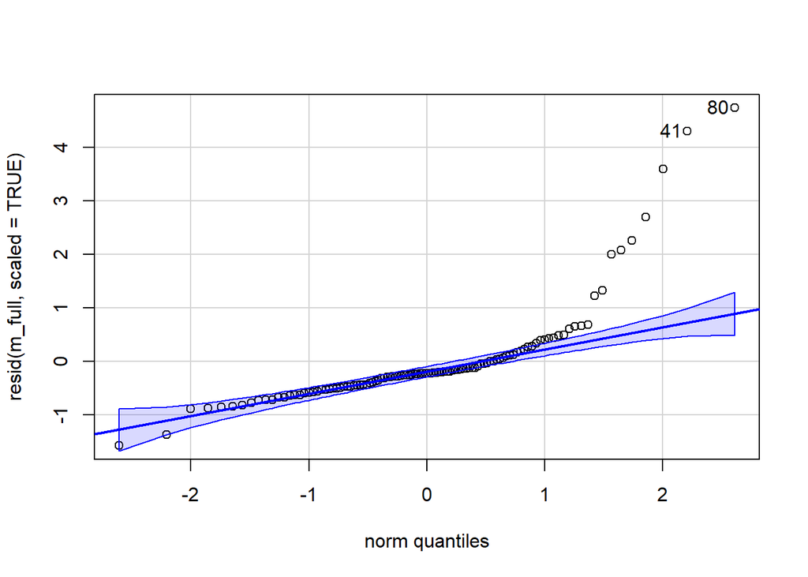

```
## [1] 80 41
```

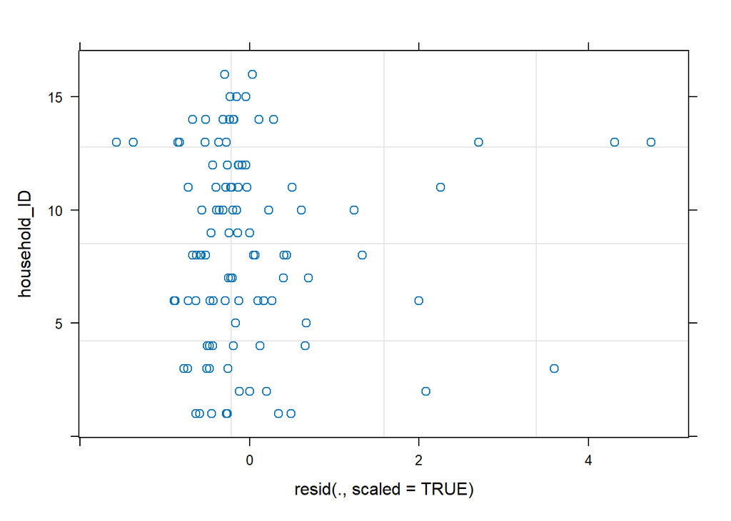

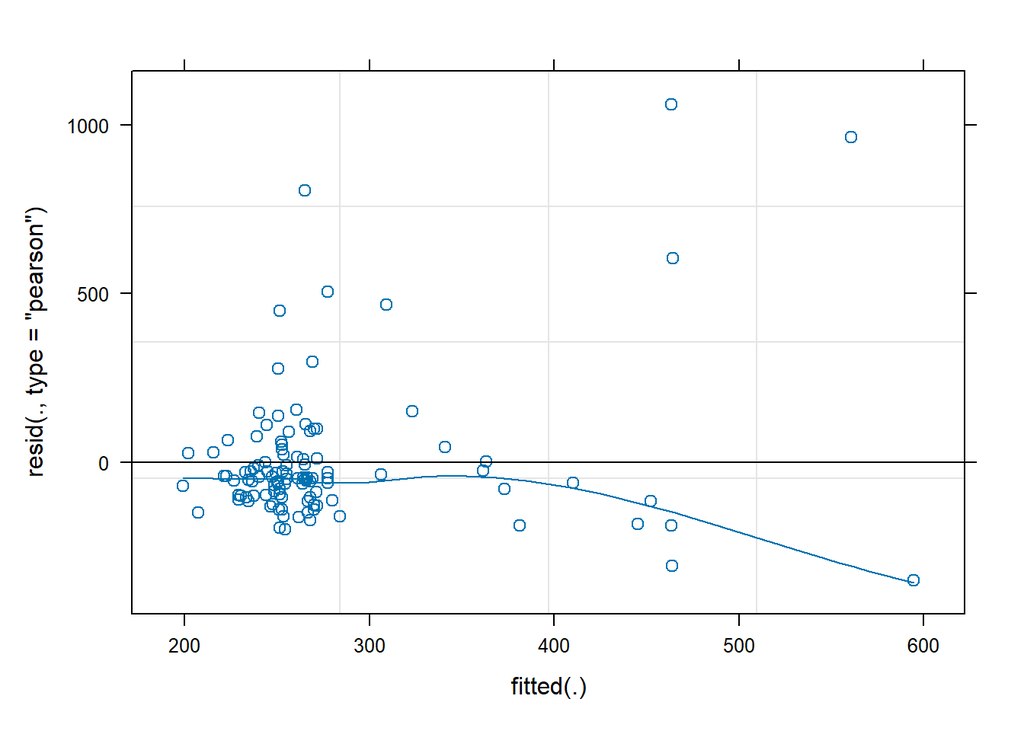

There are indications of outliers and non-normality, so results should be interpreted with caution.

##### Statistical inference of time effect

```
## refitting model(s) with ML (instead of REML)
```

```
## Data: receipt_data
## Models:
## m_null: rcpt_CO2_g_100g ~ 1 + (1 | household_ID)
## m_full: rcpt_CO2_g_100g ~ day_recorded + (1 + day_recorded | household_ID)
##        npar    AIC    BIC  logLik deviance  Chisq Df Pr(>Chisq)
## m_null    3 1520.0 1528.1 -757.00   1514.0
## m_full    6 1524.8 1541.0 -756.39   1512.8 1.2137  3     0.7497
```

No significant impact of time on foodprint found.

### Using a Skillings-Mack tests (Non-parametric alternative)

```
##
## Skillings-Mack Statistic =  7.591247 , p-value =  0.816202
## Note: the p-value is based on the chi-squared distribution with d.f. =  12
##
## $Nblocks
## [1] 16
##
## $Ntreatments
## [1] 13
##
## $rawdata
##                 4           1           2             3           7           6
##  [1,] 243.9729951 178.1061402 364.6563945  167.07600000 221.2340535 699.3595241
##  [2,] 117.8495684 137.8804069 335.3534934   94.18604651 210.0000000  55.0000000
##  [3,] 131.3440860 315.4109431 385.5332750  162.45614035 211.8880325 155.2873563
```

[output cut: 92 more lines]

The non-parametric test shows no significant impact of time.

### Paired t-test (parametric) of receipts in -1SD vs. 1SD of active scanning period

#### Visual trends

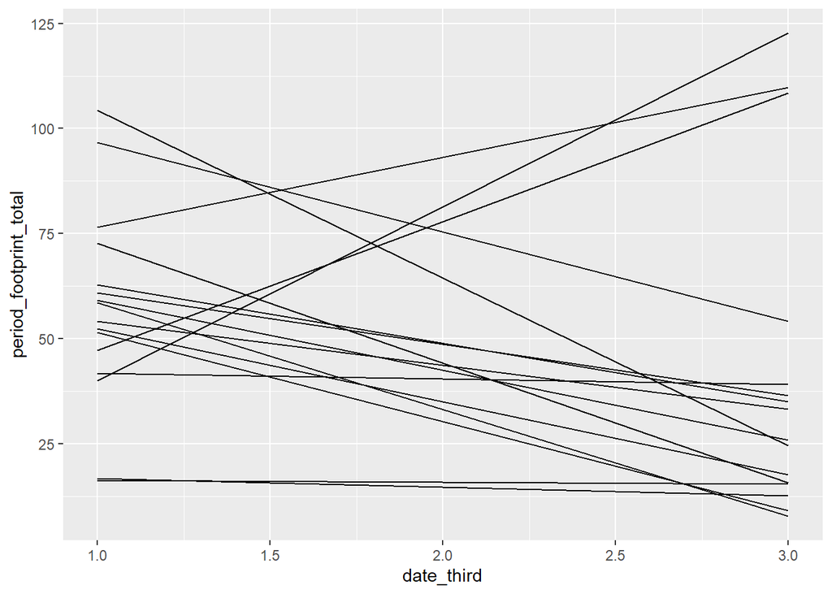

#### Paired t-test statistic

```
##
##  Paired t-test
##
## data:  ttest_data$period.1 and ttest_data$period.3
## t = -0.41320793, df = 15, p-value = 0.6853008
## alternative hypothesis: true mean difference is not equal to 0
## 95 percent confidence interval:
##  -1.1301142276  0.7630926054
## sample estimates:
## mean difference
##   -0.1835108111
```

Non-significant. The is no indication of foodprint change.